# Data Science Transport

Schulze, Michael

1/10/2021

## Preface

This is the [code](https://github.com/bernd886/data-science-transport-mid-assign-wise-2021) of a mid-semester assignment for the TU Berlin Module [Data Science for agent-based transport simulations WiSe 20/21](https://web.archive.org/web/20210207122933if_/https://moseskonto.tu-berlin.de/moses/modultransfersystem/bolognamodule/beschreibung/anzeigen.html?number=50921&version=1&sprache=2). The aim was to look into the [GTFS Data of the VBB Berlin](https://www.vbb.de/unsere-themen/vbbdigital/api-entwicklerinfos/datensaetze) transport association, published on the [28th December 2020](http://transitfeeds.com/p/verkehrsverbund-berlin-brandenburg/213/20201228).

```r
# setwd for switching between folders
setwd_gtfs <- function(){setwd("~/DataScienceTransport/data/vbb-gtfs")}
setwd_data <- function(){setwd("~/DataScienceTransport/data")}
setwd_work <- function(){setwd("~/DataScienceTransport/assignment_1")}

# reading the file
setwd_gtfs()
gtfs_vbb_2020_12 <- read_gtfs("2020-12_2020-12-28.zip")
setwd_work()

# single out the data sets
routes = gtfs_vbb_2020_12$routes
stops = gtfs_vbb_2020_12$stops
trips = gtfs_vbb_2020_12$trips
transfers = gtfs_vbb_2020_12$transfers
agency = gtfs_vbb_2020_12$agency
stoptime = gtfs_vbb_2020_12$stop_times
```

## Preparation

Trying to get some interesting data on the service density, we want to count the passings of each stop. By that we get the information about how often a stop location is serviced. The analysis was reduced to the agencies [BVG](https://en.wikipedia.org/wiki/Berliner_Verkehrsbetriebe) and [S-Bahn Berlin](https://en.wikipedia.org/wiki/Berlin_S-Bahn). The modes were limited to bus (BVG), tram (~light train) (BVG), U-Bahn (~metro) (BVG) and S-Bahn (DB). Since the most services are symmetrical, we don’t want to count the stop passings of one stop location for two directions. One direction should be deleted from the data set. Trying not to remove a non symmetrical service, like the [Ring-Bahn](https://en.wikipedia.org/wiki/Berlin_Ringbahn), we identified all non symmetrical services, whose data points won’t be touched. This proufed to be unneccesary since non symmetrical service only have a *direction_id 0*. So, deleting by *direction_id 1* would have been enough.

```r
# identify non symmetrical services
one_directer <- routes %>%
  left_join(trips) %>%
  select(route_id, route_short_name, agency_id, route_type, trip_headsign, direction_id) %>%
  group_by(route_short_name) %>%
  summarise(uni_dir = (unique(direction_id))) %>%
  count(route_short_name) %>%
  filter(n < 2) %>%
  select(route_short_name)
one_directer <- one_directer[["route_short_name"]]

head(one_directer)
```

```
## [1] "114" "175" "234" "271" "275" "312"
```

```r
# Filter for BVG and S-Bahn Berlin
agency_filter = "[Bb]erlin"

# Get coordinates for each stop
berlin = agency %>%
  select(agency_id, agency_name) %>%
  filter(str_detect(agency_name, agency_filter)) %>%
  inner_join(select(routes, route_short_name, agency_id, route_id, route_type)) %>%
  inner_join(select(trips, route_id, trip_id)) %>%
  inner_join(select(stoptime, trip_id, stop_id)) %>%
  select(-trip_id) %>% unique() %>%
  inner_join(select(stops, stop_id, stop_name, lat=stop_lat, lon=stop_lon)) %>%
  unique()
# building a selective stops count tibble including the counts of trips passings
berlin_cnt = agency %>%
  select(agency_id, agency_name) %>%
  filter(str_detect(agency_name, agency_filter)) %>%
  inner_join(select(routes, route_short_name, agency_id, route_id, route_type)) %>%
  inner_join(select(trips, route_id, trip_id, direction_id)) %>%
  # filter out one direction for symmetrical service
  filter(route_short_name %in% one_directer | !(route_short_name %in% one_directer) & direction_id == 0) %>%
  inner_join(select(stoptime, trip_id, stop_id)) %>%
  group_by(agency_id, stop_id, route_type) %>% summarise(cnt = n()) %>%
  inner_join(select(stops, stop_id, stop_name, lat = stop_lat, lon = stop_lon)) %>%
  unique()
head(berlin_cnt)
```

```
## # A tibble: 6 x 7
## # Groups:   agency_id, stop_id [6]
##   agency_id stop_id      route_type   cnt stop_name                    lat   lon
##   <chr>     <chr>             <int> <int> <chr>                      <dbl> <dbl>
## 1 1         060000171526        700   232 Berlin, Bentschener Weg     52.5  13.5
## 2 1         060000171531        700   728 Berlin, Oberfeldstr.        52.5  13.6
## 3 1         060000171533        700   325 Berlin, Schlosspark Biesd…  52.5  13.6
## 4 1         060000176524        700   403 Berlin, Alt-Mahlsdorf       52.5  13.6
## 5 1         060000320112        700   630 Neuenhagen, Schäferplatz    52.5  13.7
## 6 1         060000320550        700   224 Strausberg, Am Annatal      52.6  13.9
```

We can limit the analysis by filtering out some modes. Ferries were of no interest. The massive data points for the busses can dominate any map plots.

```r
berlin = berlin %>%
  filter(route_type != 1000) # remove ferries
  # filter(route_type != 700) # remove busses

  # berlin_cnt = berlin_cnt %>%
  # filter(route_type != 700)
```

## Plotting stop locations and passings count

This plots the stops by location and modifies the circle size based on the ranked insed the mode.

```r
# colour definition (modes)
berlin_modes = data.frame(route_type = c(700, 109, 400, 900),
                          mot = factor(x = c("Bus", "SBahn", "UBahn", "Tram"),
                                       levels = c("Bus", "SBahn", "UBahn", "Tram")
                                       )
                          )
factpal = colorFactor(palette = c("#9b266d", "#368334", "#4990bc", "#c50800"),
                      domain = berlin_modes$mot,
                      levels = levels(berlin_modes$mot),
                      ordered = FALSE,
                      na.color = "#808080",
                      alpha = FALSE
                      )

# add modes to berlin stop count
# add bins to each MoT group for plot
berlin_cnt = berlin_cnt %>%
  left_join(berlin_modes) %>%
  group_by(mot) %>%
  mutate(bin = ntile(cnt, n = 8))
# preview the available map backgrounds: https://leaflet-extras.github.io/leaflet-providers/preview/
m = leaflet() %>%
  # Add CartoDB background map
  addProviderTiles("CartoDB.DarkMatter") %>%
  # Add a marker for each stop
  addCircleMarkers(lng= ~ lon, lat= ~lat, data = berlin_cnt,
                   stroke = FALSE, fillOpacity = 0.5, radius = ~(bin/2),
                   # adjust radius depending on deseired view
                   color = ~ factpal(mot)
                   ) %>%
  addLegend(colors = c("#9b266d", "#368334", "#4990bc", "#c50800"),
            labels = levels(berlin_cnt$mot), title = "Mode of Transport")
m  # Show
```

[interactive chart not shown]

## Plotting service density by districs

### Preration

Trying to aggregate the information of the stop passings count, we focused on a analysis by districts. For this we need the shapes. [The files](https://web.archive.org/web/20190624123508/https://www.stadtentwicklung.berlin.de/planen/basisdaten_stadtentwicklung/lor/de/download.shtml) also include the more detailed [LOR](https://de.wikipedia.org/wiki/Lebensweltlich_orientierte_R%C3%A4ume).

```r
# Prognoseraum - lor_pgr
# Bezirksregion - lor_bzr
# Planungsraum - lor_plr

# read data
setwd_data()
shape_districts_new <- read_sf(dsn = "LOR_SHP_2019-1", layer = "Planungsraum_EPSG_25833")
setwd_work()

# wrangle
shape_districts_new <- shape_districts_new %>%
  group_by(BEZIRK) %>%
  summarise() %>%
  filter(!is.na(BEZIRK)) %>%
  rename(NAME = BEZIRK) %>%
  mutate(AREA = st_area(geometry)) %>%
  select(NAME, AREA, everything())

# setting crs of polygons
st_crs(shape_districts_new$geometry) <- 25833
```

Maybe one can combine the service information by district with [data about the population](https://web.archive.org/web/20201031083148/https://daten.berlin.de/datensaetze/einwohnerinnen-und-einwohner-den-ortsteilen-berlins-am-31122019).

```
## # A tibble: 6 x 2
##   DISTRICT_NAME              POPULATION
##   <chr>                           <dbl>
## 1 Charlottenburg-Wilmersdorf     343592
## 2 Friedrichshain-Kreuzberg       290386
## 3 Lichtenberg                    294201
## 4 Marzahn-Hellersdorf            269967
## 5 Mitte                          385748
## 6 Neukölln                       329917
```

The population data can be merged with the districts shapes. One has to make sure that it stays a sf object.

```r
# merging
shape_super <- pop_districts_sum %>%
  rename(NAME = DISTRICT_NAME) %>%
  left_join(shape_districts_new) %>%
  st_sf()
# transforming stop coordinates
points <- data.frame(lon = berlin_cnt$lon,
                     lat = berlin_cnt$lat) %>%
  st_as_sf(coords = c("lon", "lat"), crs = 4326, agr = "constant") %>%
  st_transform(25833)

# adding to berlin_cnt
berlin_cnt <- berlin_cnt %>%
  ungroup() %>%
  add_column(point = points$geometry) %>%
  select(-lat, -lon)

remove(points)

head(berlin_cnt)
```

```
## # A tibble: 6 x 8
##   agency_id stop_id route_type   cnt stop_name mot     bin
##   <chr>     <chr>        <dbl> <int> <chr>     <fct> <int>
## 1 1         060000…        700   232 Berlin, … Bus       3
## 2 1         060000…        700   728 Berlin, … Bus       8
## 3 1         060000…        700   325 Berlin, … Bus       5
## 4 1         060000…        700   403 Berlin, … Bus       6
## 5 1         060000…        700   630 Neuenhag… Bus       7
## 6 1         060000…        700   224 Strausbe… Bus       3
## # … with 1 more variable: point <POINT [m]>
```

Finishing the final tibble icluding all data for the plot of stop passings by districts. In our case (mot = NA) means ferries and (bezirk = NA) hints at a data point outside berlin. The steps of data wrangling include: - getting the districts name of the stop

- getting the sum of all stops passings per district
- removing outer berlin and ferries
- pivoting into wider form for modes
- replacing NAs with zeros
- join with the district shapes
- setting as sf object (attribute keeps getting lost by joining (needed for plot))

```r
berlin_cnt_super <- berlin_cnt %>%
  mutate(
    bezirk = shape_super[as.numeric(st_within(point, shape_super)),]$NAME
    ) %>%
  group_by(bezirk, mot) %>%
  summarise(n = sum(cnt)) %>%
  filter(
    !(is.na(bezirk)) & !(is.na(mot))
    ) %>%
  pivot_wider(names_from = mot, values_from = n) %>%
  mutate_all(
    ~replace(., is.na(.), 0)
    )%>%
  rename(NAME = bezirk,
         BUS = Bus,
         SBAHN = SBahn,
         UBAHN = UBahn,
         TRAM = Tram
         ) %>%
  mutate(
    ALL_MODES = sum(BUS, TRAM, SBAHN, UBAHN)
    ) %>%
  left_join(shape_super) %>%
  select(NAME, POPULATION, AREA,
         BUS, TRAM, UBAHN,
         SBAHN, ALL_MODES, geometry
         ) %>%
  st_sf()
```

```
## `mutate_all()` ignored the following grouping variables:
## Column `bezirk`
## Use `mutate_at(df, vars(-group_cols()), myoperation)` to silence the message.
```

```r
head(berlin_cnt_super)
```

```
## Simple feature collection with 6 features and 8 fields
## geometry type:  POLYGON
## dimension:      XY
## bbox:           xmin: 376875.9 ymin: 5806165 xmax: 408990.7 ymax: 5828431
## projected CRS:  ETRS89 / UTM zone 33N
## # A tibble: 6 x 9
## # Groups:   NAME [6]
##   NAME  POPULATION   AREA    BUS  TRAM UBAHN SBAHN ALL_MODES
##   <chr>      <dbl>  <dbl>  <dbl> <dbl> <dbl> <dbl>     <dbl>
## 1 Char…     343592 6.47e7 151784     0 28638 20606    201028
## 2 Frie…     290386 2.04e7  73522 21449 17374  8905    121250
## 3 Lich…     294201 5.21e7  54898 63505  4131  7815    130349
## 4 Marz…     269967 6.18e7  89041 36835  6047  5936    137859
## 5 Mitte     385748 3.94e7 126782 53599 34325 21155    235861
## 6 Neuk…     329917 4.49e7 147657     0 13969  5781    167407
## # … with 1 more variable: geometry <POLYGON [m]>
```

It would be nice to have the number of stops per mode, but one can see a lot of stops per route unused by main line service, used by detour trips (maybe caused by construction work). More work is necessary.

Only rough conclusions concerning the spatial distribution of service are possible. They might really be misleading and if not, should be made by mode with the network in mind.

### Barplot

This barplot shows the stop passings by districs.

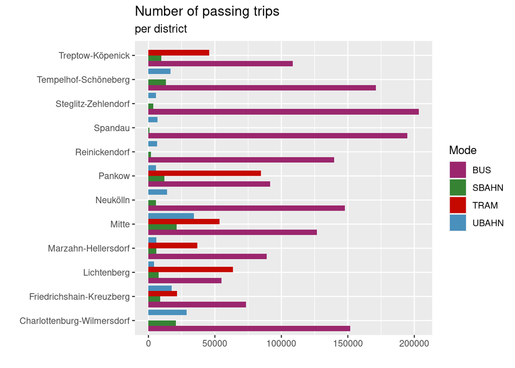

```r
plot_bar_cnt <- berlin_cnt_super %>%
  st_drop_geometry() %>%
  pivot_longer(c(BUS, TRAM, UBAHN, SBAHN), names_to = "MODE", values_to = "N") %>%
  ggplot() +
  geom_bar(mapping = aes(x = NAME, y = N, fill = MODE),
           stat = "identity",
           position = "dodge") +
  coord_flip() +
  guides(x = guide_axis(angle = 0)) +
  scale_fill_manual(
    values = c("#9b266d", "#368334", "#c50800", "#4990bc")
    ) +
  theme() +
  labs(title = "Number of passing trips",
       subtitle = "per district",
       x = "",
       y = "",
       fill = "Mode"
       )

plot_bar_cnt
```

### Reminder: population density

If we want to use the data on the population size / age, it’s useful to remind us of the denisty per district (we didn’t find more detailed information).

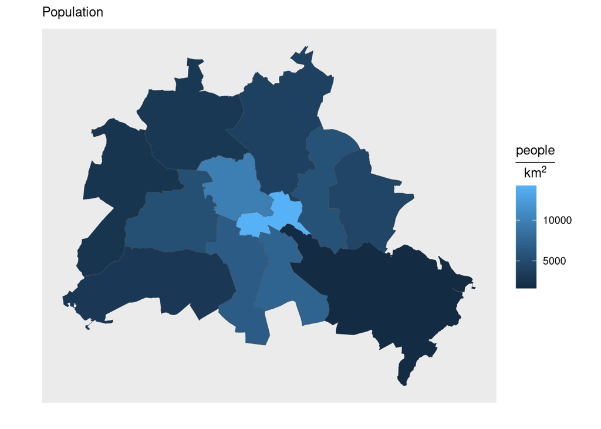

```r
lwd = 0.1

plot_distr_pop <- berlin_cnt_super %>%
  mutate(
    POP_DENSITY = POPULATION / (AREA / 1000000)
    ) %>%
  ggplot() +
  geom_sf(mapping = aes(fill = POP_DENSITY),
          show.legend = TRUE,
          lwd = lwd,
          ) +
  theme(panel.grid.major = element_blank(),
        panel.grid.minor = element_blank(),
        #plot.background = element_rect(fill = "#000000", color = "black"),
        #panel.background = element_rect(fill = "#000000", color = "black"),
        axis.text.x = element_blank(),
        axis.text.y = element_blank(),
        axis.ticks.x = element_blank(),
        axis.ticks.y = element_blank(),
        ) +
  labs(#title = "Density",
       #subtitle = expression(paste("Population [people / ", km^2, "]")),
       subtitle = expression(paste("Population")),
       x = "",
       y = "",
       #fill = element_blank()
       fill = expression(paste(frac("people", km^2)))
       )

plot_distr_pop
```

## Service density plot by district

First we look at stops passings density by district area size for all modes. For further plots, look into Rmd file or modify the code. The things that change are the tibble column, colour palette, subtitle and legend title.

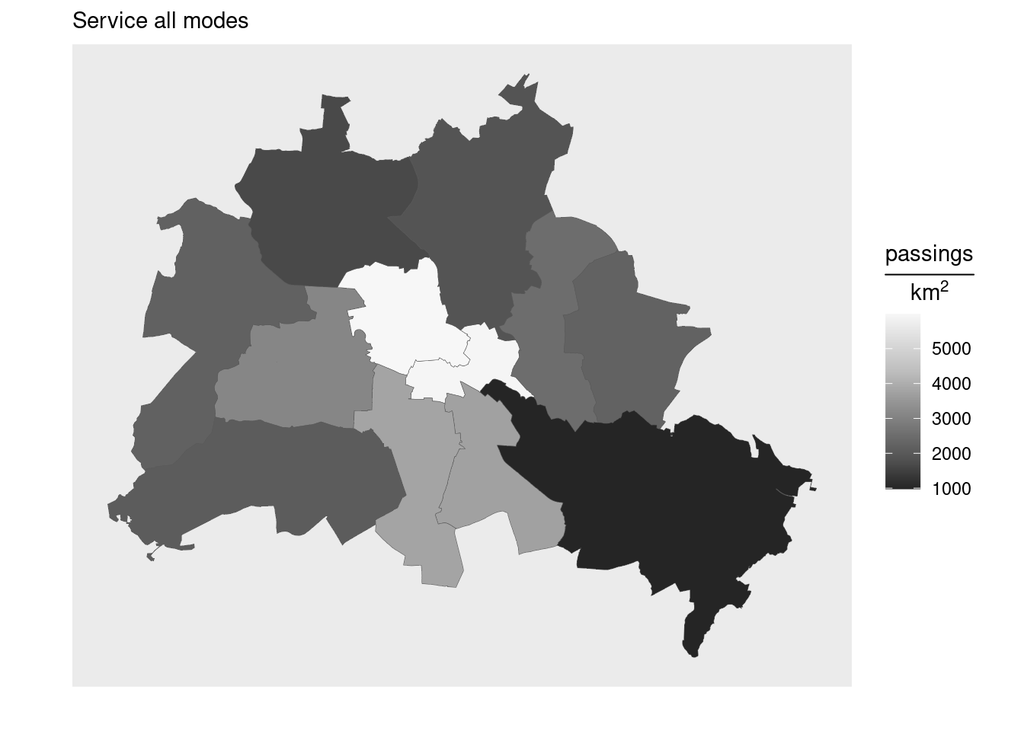

```r
plot_distr_serv_all <- berlin_cnt_super %>%
  mutate(
    STOP_SERVICE_DENSITY = ALL_MODES / (AREA / 1000000)
    ) %>%
  ggplot() +
  geom_sf(mapping = aes(fill = STOP_SERVICE_DENSITY),
          show.legend = TRUE,
          lwd = lwd
          ) +
  scale_fill_distiller(palette = "Greys") +
  theme(panel.grid.major = element_blank(),
        panel.grid.minor = element_blank(),
        #plot.background = element_rect(fill = "#000000", color = "black"),
        #panel.background = element_rect(fill = "#000000", color = "black"),
        axis.line.x = element_blank(),
        axis.line.y = element_blank(),
        axis.text.x = element_blank(),
        axis.text.y = element_blank(),
        axis.ticks.x = element_blank(),
        axis.ticks.y = element_blank()
        ) +
  labs(#title = "Service density all modes",
       #subtitle = expression(paste("Service all modes [passings / ", km^2, "]")),
       subtitle = expression(paste("Service all modes")),
       x = "",
       y = "",
       #fill = element_blank()
       fill = expression(paste(frac("passings", km^2)))
       )

plot_distr_serv_all
```

Can we get some insight by plotting the stop passings count against the population size?

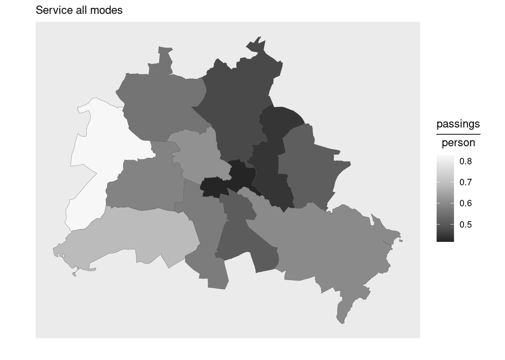

One thing we can see is that Spandau is blessed with a lot of stop passings (especially bus) compared with its low population density.

## Service density plot by Planungsraum

The mapping by district is very coarse. We switch to plotting by mode and by the more detailed Planungsräume. Here the code for one mode.

```r
# reread data after wrangling
setwd_data()
shape_districts_parts <- read_sf(dsn = "LOR_SHP_2019-1", layer = "Planungsraum_EPSG_25833")
setwd_work()

shape_districts_parts <- shape_districts_parts %>%
  group_by(SCHLUESSEL) %>%
  summarise() %>%
  filter(!is.na(SCHLUESSEL)) %>%
  #rename(NAME = BEZIRKSREG) %>%
  mutate(AREA = st_area(geometry)) %>%
  select(SCHLUESSEL, AREA, everything()) %>%
  st_sf()

st_crs(shape_districts_parts) <- 25833

# pepare data for different plots
pre_plot_part <- berlin_cnt %>%
  mutate(
    SCHLUESSEL = shape_districts_parts[as.numeric(st_within(point, shape_districts_parts)),]$SCHLUESSEL
  ) %>%
  group_by(SCHLUESSEL, mot) %>%
  summarise(n = sum(cnt)) %>%
  filter(
    !(is.na(SCHLUESSEL)) & !(is.na(mot))
  ) %>%
  pivot_wider(names_from = mot, values_from = n) %>%
  mutate_all(
    ~replace(., is.na(.), 0)
  ) %>%
  rename(BUS = Bus,
         SBAHN = SBahn,
         UBAHN = UBahn,
         TRAM = Tram
  ) %>%
  mutate(
    ALL_MODES = sum(BUS, TRAM, SBAHN, UBAHN)
  ) %>%
  left_join(shape_districts_parts) %>%
  select(SCHLUESSEL, AREA, BUS,
         TRAM, UBAHN, SBAHN,
         ALL_MODES, geometry
  ) %>%
  st_sf()
```

```
## `mutate_all()` ignored the following grouping variables:
## Column `SCHLUESSEL`
## Use `mutate_at(df, vars(-group_cols()), myoperation)` to silence the message.
```

```r
head(pre_plot_part)
```

```
## Simple feature collection with 6 features and 7 fields
## geometry type:  MULTIPOLYGON
## dimension:      XY
## bbox:           xmin: 386668.2 ymin: 5817761 xmax: 390764.3 ymax: 5820432
## projected CRS:  ETRS89 / UTM zone 33N
## # A tibble: 6 x 8
## # Groups:   SCHLUESSEL [6]
##   SCHLUESSEL    AREA   BUS  TRAM UBAHN SBAHN ALL_MODES                  geometry
##   <chr>        <dbl> <dbl> <dbl> <dbl> <dbl>     <dbl>        <MULTIPOLYGON [m]>
## 1 01011101    3.67e5  3238     0     0     0      3238 (((387256.6 5818552, 387…
## 2 01011102    3.01e6  5001     0   838     0      5839 (((386767.5 5819393, 386…
## 3 01011103    5.22e5  4465     0     0     0      4465 (((387952.6 5818275, 387…
## 4 01011104    3.38e5  2180     0   854     0      3034 (((388847.1 5817875, 388…
## 5 01011105    9.35e5  8986     0  1123     0     10109 (((388129.5 5819015, 388…
## 6 01011201    6.34e5  5501     0  2252   569      8322 (((389845.7 5819286, 389…
```

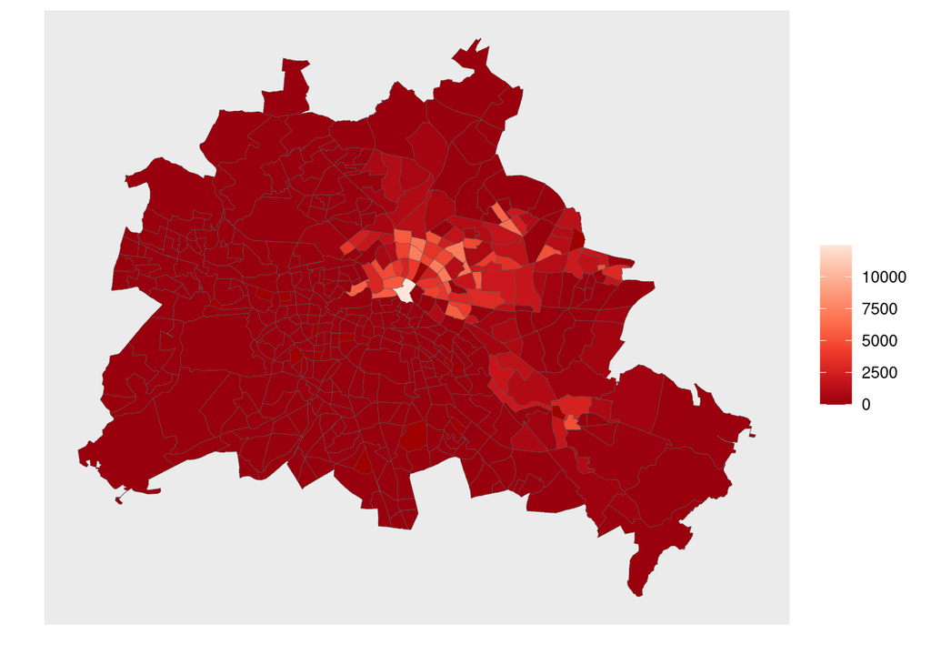

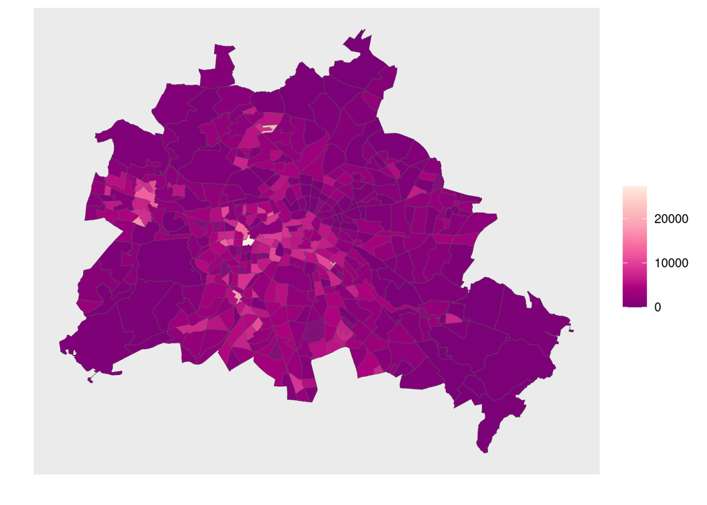

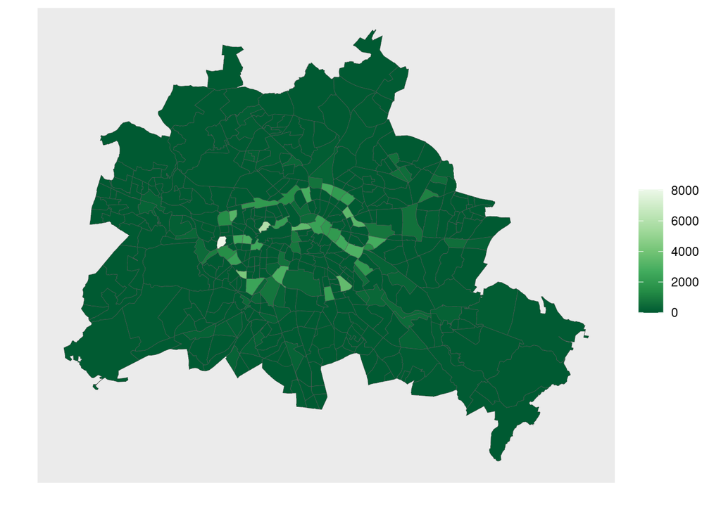

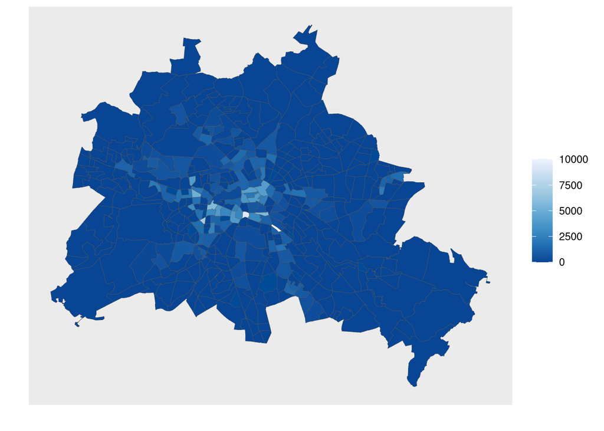

```r
# plot stop passings by planungsraum for tram
plot_plan_serv_tram <- pre_plot_part %>%
  mutate(
    STOP_SERVICE_DENSITY = TRAM / (AREA / 1000000)
    ) %>%
  ggplot() +
  # extra underlying black shape, because transparent polygons
  geom_sf(data = shape_districts_new,
          fill = "#9f0000",
          lwd = 0,
          show.legend = FALSE
          ) +
  geom_sf(mapping = aes(fill = STOP_SERVICE_DENSITY),
          lwd = lwd,
          show.legend = TRUE
          ) +
  theme(panel.grid.major = element_blank(),
        panel.grid.minor = element_blank(),
        #plot.background = element_rect(fill = "#000000", color = "black"),
        #panel.background = element_rect(fill = "#000000", color = "black"),
        axis.line.x = element_blank(),
        axis.line.y = element_blank(),
        axis.text.x = element_blank(),
        axis.text.y = element_blank(),
        axis.ticks.x = element_blank(),
        axis.ticks.y = element_blank()
        ) +
  scale_fill_distiller(palette = "Reds") +
  labs(#title = "Service all modes per Planungsraum",
    #subtitle = expression(paste("Service TRAM per Planungsraum [passings / ", km^2, "]")),
    x = "",
    y = "",
    fill = element_blank()
    )

plot_plan_serv_tram
```

## list of sources

Datafeelings: [Visualizing GTFS Data in R](https://rpubs.com/data_feelings/data607_gtfs)

Mel Moreno, Mathieu Basille (2018): [Drawing beautiful maps programmatically with R, sf and ggplot2 — Part 2: Layers](https://www.r-spatial.org/r/2018/10/25/ggplot2-sf-2.html)

Edzer Pebesma: [Transform or convert coordinates of simple feature](https://r-spatial.github.io/sf/reference/st_transform.html)

Kazuhito [stackexchange] (2017): [Lon-Lat to Simple Features (sfg and sfc) in R](https://gis.stackexchange.com/questions/222978/lon-lat-to-simple-features-sfg-and-sfc-in-r)

einar, kevinykuo [stackoverflow] (2017): [How to find which polygon a point belong to via sf](https://stackoverflow.com/questions/43456524/how-to-find-which-polygon-a-point-belong-to-via-sf)

aL3xa, leerssej [stackoverflow] (2017): [How do I replace NA values with zeros in an R dataframe?](https://stackoverflow.com/questions/8161836/how-do-i-replace-na-values-with-zeros-in-an-r-dataframe#8166616)

RStudio: [CheatSheets](https://rstudio.com/resources/cheatsheets/) (Simple Features, leaflet, data.table, R Markdown, Data Transformation, Data Import)